# Assignment 3

Arthur Junges Schmidt

31 July 2020

# Problem 1

## a)

The file ps3-1.csv contains a data set with 34 features (x1, x2, … x34) and 1 target variable (Y). Estimate a classifier model using Support Vector Machine and Random Forest algorithm in R, respectively, with the first 14628 rows of the data. Optimize your model so that a False Positive Rate is less than 10% for Y = 0 (actual Y = 1 cases falsely classified as Y = 0). Particularly, you are required to review relevant literature, use the k-fold cross-validation method to train the Random Forest model. Use grid search to find hyper-parameter setting: the best number of trees and features, maximum leaf nodes. Assess importance of each feature based on two criteria: Mean Decrease Accuracy and Mean Decrease Gini. Compare two estimation methods with confusion matrices

```r
Crude_Data <- read.csv("ps3-1.csv");
Crude_Data <- Crude_Data[,-1];
Crude_Data$Y <- factor(Crude_Data$Y, levels = c(0,1));
Training_Data <- Crude_Data[1:14628, ];
Test_Data <- Crude_Data[-(1:14628), ];
```

### SVM

Firstly, a cluster with 3 processors is created. The library randomForest is loaded for the future runs of the random forest models.

Radial SVM were tried but didn’t present better accuracy values while taking much longer to finish. For the linear SVM models, only the cost parameter is tuned. For cost values greater than 10, the models take an enormous amount of time to run. Because of this, the cost values tested are 10^{-4}, 0.001, 0.01, 0.1, 1, 10.

```r
###### Cluster creation for usage of 4 processor cores

cluster <- makeCluster(3, outfile = "cluster_log.txt")
clusterEvalQ(cluster, library(randomForest))
```

```
## [[1]]
## [1] "randomForest" "stats"        "graphics"     "grDevices"    "utils"        "datasets"     "methods"      "base"
##
## [[2]]
## [1] "randomForest" "stats"        "graphics"     "grDevices"    "utils"        "datasets"     "methods"      "base"
##
## [[3]]
## [1] "randomForest" "stats"        "graphics"     "grDevices"    "utils"        "datasets"     "methods"      "base"
```

```r
registerDoParallel(cluster)


SVM_tunegrid <- expand.grid(C = 10^(-4:1))
SVM_trControl <-  trainControl("cv", number = 10,
                               verboseIter = TRUE)

Start_Time1 <- Sys.time()

SVM_Fit <- train(Y ~ ., data = Training_Data,
                 method = 'svmLinear', tuneGrid = SVM_tunegrid,
                 preProcess = c("center", "scale"),
                 trControl = SVM_trControl
                 )
End_time1 <- Sys.time()
End_time1 - Start_Time1
```

```
## Time difference of 42.19323 mins
```

```r
beep(sound = 3)
SVM_Fit
```

```
## Support Vector Machines with Linear Kernel
##
## 14628 samples
##    34 predictor
##     2 classes: '0', '1'
##
## Pre-processing: centered (34), scaled (34)
## Resampling: Cross-Validated (10 fold)
## Summary of sample sizes: 13165, 13165, 13165, 13165, 13166, 13165, ...
## Resampling results across tuning parameters:
##
##   C      Accuracy   Kappa
##   1e-04  0.7748838  0.0003333768
##   1e-03  0.7871882  0.1421108242
##   1e-02  0.7873250  0.1576728574
##   1e-01  0.7879402  0.1619824177
##   1e+00  0.7880086  0.1623765541
##   1e+01  0.7749521  0.0004704106
##
## Accuracy was used to select the optimal model using the largest value.
## The final value used for the model was C = 1.
```

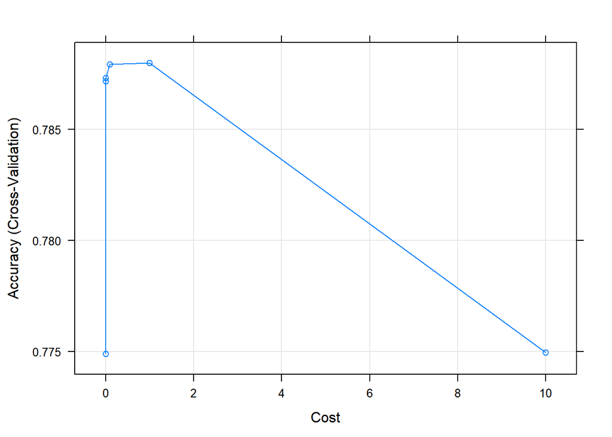

```r
plot(SVM_Fit)
```

```r
# stopCluster(cluster)
```

```r
confusionMatrix(SVM_Fit)
```

```
## Cross-Validated (10 fold) Confusion Matrix
##
## (entries are percentual average cell counts across resamples)
##
##           Reference
## Prediction    0    1
##          0  3.2  1.9
##          1 19.3 75.6
##
##  Accuracy (average) : 0.788
```

```r
confusionMatrix(SVM_Fit, scale = FALSE, norm = "none")
```

```
## Cross-Validated (10 fold) Confusion Matrix
##
## (entries are un-normalized aggregated counts)
##
##           Reference
## Prediction     0     1
##          0   468   276
##          1  2825 11059
##
##  Accuracy (average) : 0.788
```

### Random Forest

Very conveniently, the Caret package in R enables the user to modify the ‘train’ function with more options for parameter tuning. Originally, the only parameter accepted for tuning is ‘mtry’. However, with the code below, the ‘ntre’ (number of trees) and ‘maxnode’ (maximum number of leaves) are added as tunable parameter. Additionally, these parameters are easily compared with the plot function after the training process. The time to train the random forest model with a wide grid of paramenters is very long. After many trials, these parameters in the code below showed the best results. If a wider range of values would have been used, the training process would take longer than 2 hours.

Cross validation is used, with the method “cv” on the traincontrol parameters. 10 folds of the data were used.

```r
customRF <- list(type = "Classification",
                 library = "randomForest",
                 loop = NULL)

customRF$parameters <- data.frame(parameter = c("mtry", "ntree", "maxnodes"),
                                  class = rep("numeric", 3),
                                  label = c("mtry", "ntree", "maxnodes"))

customRF$grid <- function(x, y, len = NULL, search = "grid") {}

customRF$fit <- function(x, y, wts, param, lev, last, weights, classProbs) {
  randomForest(x, y,
               mtry = param$mtry,
               ntree=param$ntree,
               maxnodes = param$maxnodes)
}
# customRF$varImp = randomForest::importance()


#Predict label
customRF$predict <- function(modelFit, newdata, preProc = NULL, submodels = NULL)
   predict(modelFit, newdata)

#Predict prob
customRF$prob <- function(modelFit, newdata, preProc = NULL, submodels = NULL)
   predict(modelFit, newdata, type = "prob")

customRF$sort <- function(x) x[order(x[,1]),]
customRF$levels <- function(x) x$classes
###### Cluster creation for usage of 4 processor cores

# cluster <- makeCluster(4, outfile = "cluster_log.txt")

# registerDoParallel(cluster)

######
control <- trainControl(method="cv",
                        number=10,
                        allowParallel = TRUE,
                        verboseIter = TRUE
                        )

tunegrid <- expand.grid(.mtry=c(6, 12, 18),.ntree=c(100, 200, 500, 1000),
                        .maxnodes= seq(40, 80, by = 10))

set.seed(123)
Start_Time <- Sys.time()
RF_fit <- train(Y ~ ., data=Training_Data,
                method=customRF,
                metric="Accuracy",
                tuneGrid=tunegrid,
                trControl=control,
                preProcess = c("center", "scale"))
RF_fit
```

```
## 14628 samples
##    34 predictor
##     2 classes: '0', '1'
##
## Pre-processing: centered (34), scaled (34)
## Resampling: Cross-Validated (10 fold)
## Summary of sample sizes: 13164, 13166, 13165, 13166, 13165, 13165, ...
## Resampling results across tuning parameters:
##
##   mtry  ntree  maxnodes  Accuracy   Kappa
##    6     100   40        0.7962132  0.2111804
##    6     100   50        0.7977171  0.2227248
##    6     100   60        0.7980593  0.2286118
##    6     100   70        0.7991532  0.2301188
##    6     100   80        0.7997000  0.2368729
```

[output cut: 58 more lines]

```r
beepr::beep(sound = 3)
End_time <- Sys.time()
End_time - Start_Time
```

```
## Time difference of 51.70083 mins
```

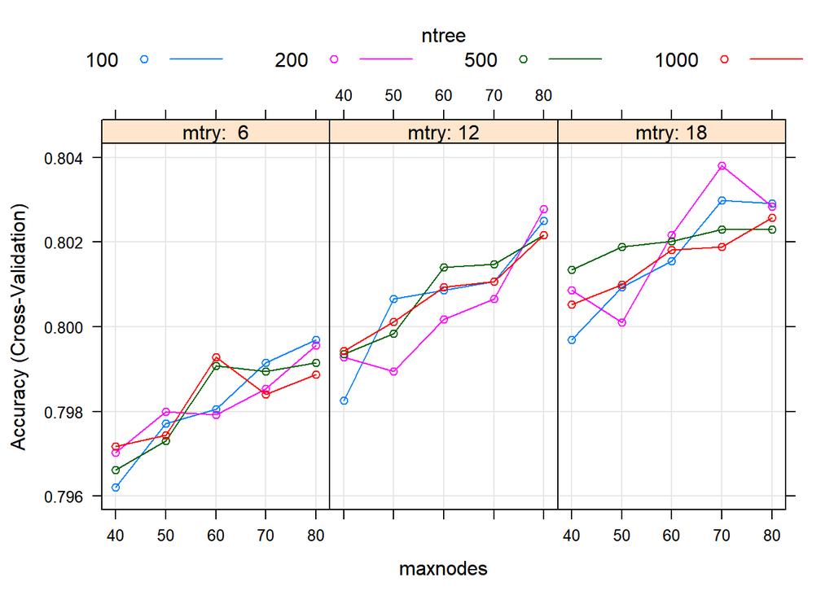

```r
stopCluster(cluster)
plot(RF_fit)
```

It can be seen that after a tree size of 500, there’s no real improvement in the model. On the contrary, the model with a $ntree = 1000$ has a lower accuracy.

For the False Negative Rate, the confusion matrix is needed. The confusion matrix is made from the best model found with the combination of the parameters. The results shown below represent the average percentage across the 10 folds.

```r
confusionMatrix.train(RF_fit, scale = FALSE)
```

```
## Cross-Validated (10 fold) Confusion Matrix
##
## (entries are percentual average cell counts across resamples)
##
##           Reference
## Prediction    0    1
##          0  5.6  2.7
##          1 16.9 74.8
##
##  Accuracy (average) : 0.8038
```

For the absolute number of predictions on the confusion matrix:

```r
confusionMatrix(RF_fit, scale = FALSE, norm = "none")
```

```
## Cross-Validated (10 fold) Confusion Matrix
##
## (entries are un-normalized aggregated counts)
##
##           Reference
## Prediction     0     1
##          0   814   391
##          1  2479 10944
##
##  Accuracy (average) : 0.8038
```

A problem on this custom model approach is that the function ‘importance()’ which returns the mean decrease accuracy and mean decrease Gini values for the variables only returns the latter. To fix this, the best model created from all the parameters is then performed on the standard ‘randomForest’ function, which will then return both values needed. The best tree found has the following parameters:

- mtry: 18
- ntree: 200
- maxnodes: 70

```r
Final_Model_RF <- randomForest::randomForest(Y ~ ., data = Training_Data,
                               importance = TRUE,
                               maxnodes = RF_fit$bestTune$maxnodes,
                               ntree = RF_fit$bestTune$ntree,
                               mtry = RF_fit$bestTune$mtry,
                               )

randomForest::importance(Final_Model_RF)
```

```
##               0         1 MeanDecreaseAccuracy MeanDecreaseGini
## X1   -2.6147406  6.532357            7.0992055       17.8025789
## X2   12.4601564 15.167279           20.0594405       88.9820446
## X3   -3.0256011  5.670771            5.2955148       17.1857916
## X4   -3.3621952  4.856525            4.4707767        4.8320120
## X5   13.3611378 12.953082           18.6489453      292.0033430
## X6    6.9400206  6.900886            9.9238195      119.2865276
## X7    4.8894348  2.947216            5.3271248       16.9165694
## X8   -2.5202602  2.458768            1.4337820        0.8216684
## X9    1.7181757  5.496642            6.6459092       47.4461398
## X10  -2.4434653  5.133153            5.2383718       12.6000675
## X11  -0.8953584  2.482791            2.6969738        3.4588216
## X12   2.8175425  3.399948            4.3979848        2.6545521
## X13  22.0172099 11.183750           25.4886727      203.6216424
## X14   9.0512828  9.669979           12.5155776       33.4257271
## X15  -0.1530629  3.523833            4.2398475        6.9710683
## X16  -4.2437046  3.438532            2.7752596       17.6323998
## X17  -0.5403401  4.611731            5.1676276       16.6504648
## X18  -4.7795132  6.993780            6.5470159       12.0106959
## X19  -1.7917273  6.591200            7.9786529       18.2517575
## X20 -14.4078158 16.092396           15.4203733       35.5187877
## X21   0.3014958  2.465283            3.4800215        9.3960929
## X22  -5.4573285  4.841351            3.4194521        9.6224899
## X23  -1.2891860  3.075554            2.8783857       16.7505535
## X24   3.2673822  7.836935            9.8328810       24.3241305
## X25   8.6498480 19.194629           22.4285083       84.5130214
## X26   2.0458763  8.847743           10.4576995       37.6912202
## X27  -3.8596117  6.422042            6.0597039       12.3724259
## X28   0.4870394  3.225704            4.1840114        8.7654874
## X29  -3.6134683  3.508466            2.0561710        8.0346586
## X30  -2.9097344  2.892135            0.9970993        5.7189032
## X31  -4.4305904  5.375859            4.1710716       10.4252541
## X32  -3.3379271  6.590472            6.2308385       14.5835591
## X33   1.9921505  9.265247           12.5137580       33.2636898
## X34  -5.1727370  8.362496            8.5799422       24.0830077
```

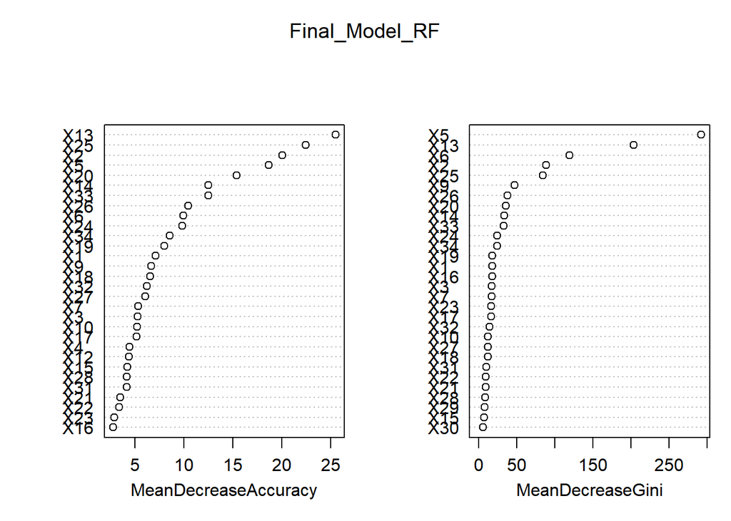

```r
varImpPlot(Final_Model_RF)
```

```r
Both_models <- resamples(list(SVM = SVM_Fit,
                              RandomForest = RF_fit))

summary(Both_models)
```

```
##
## Call:
## summary.resamples(object = Both_models)
##
## Models: SVM, RandomForest
## Number of resamples: 10
##
## Accuracy
##                   Min.   1st Qu.    Median      Mean   3rd Qu.      Max. NA's
## SVM          0.7756498 0.7850308 0.7900854 0.7880086 0.7932331 0.7949419    0
## RandomForest 0.7913817 0.7983933 0.8055362 0.8038011 0.8090920 0.8160055    0
##
## Kappa
##                   Min.   1st Qu.    Median      Mean   3rd Qu.      Max. NA's
## SVM          0.1193321 0.1524547 0.1724496 0.1623766 0.1788694 0.1817572    0
## RandomForest 0.2034334 0.2646406 0.2820759 0.2742724 0.2925561 0.3208643    0
```

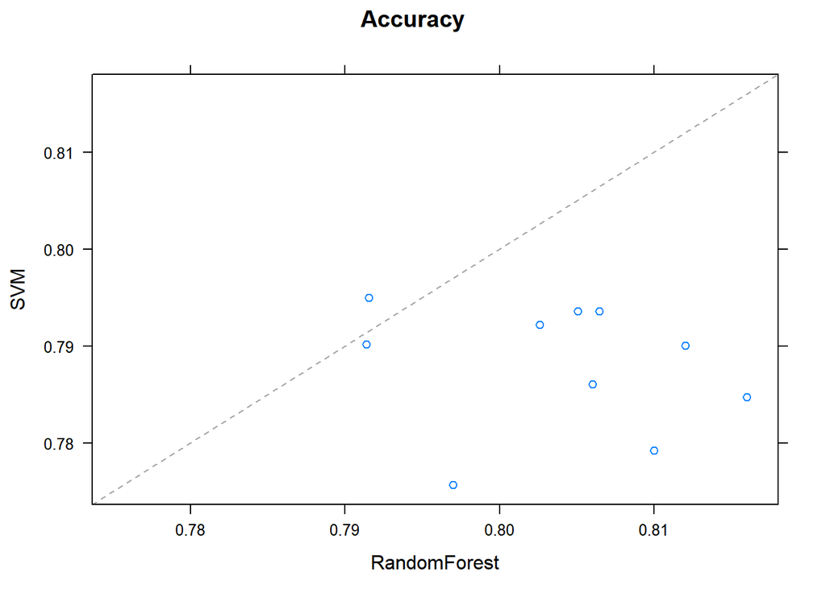

```r
xyplot(Both_models)
```

## b)

Use two estimated models to predict the last 200 rows of the data and compare prediction with the observed target value (Y).

```r
Predictions <- predict(list(SVM = SVM_Fit,
                            RandomForest = RF_fit),
                       newdata = Test_Data[, -35])

confusionMatrix(data = Predictions$SVM, reference = Test_Data[, 35])
```

```
## Confusion Matrix and Statistics
##
##           Reference
## Prediction   0   1
##          0   6   1
##          1  44 149
##
##                Accuracy : 0.775
##                  95% CI : (0.7108, 0.8309)
##     No Information Rate : 0.75
##     P-Value [Acc > NIR] : 0.2332
##
##                   Kappa : 0.1589
##
##  Mcnemar's Test P-Value : 3.825e-10
##
##             Sensitivity : 0.1200
##             Specificity : 0.9933
##          Pos Pred Value : 0.8571
##          Neg Pred Value : 0.7720
##              Prevalence : 0.2500
##          Detection Rate : 0.0300
##    Detection Prevalence : 0.0350
##       Balanced Accuracy : 0.5567
##
##        'Positive' Class : 0
##
```

```r
confusionMatrix(data = Predictions$RandomForest, reference = Test_Data[, 35])
```

```
## Confusion Matrix and Statistics
##
##           Reference
## Prediction   0   1
##          0  17   5
##          1  33 145
##
##                Accuracy : 0.81
##                  95% CI : (0.7487, 0.8619)
##     No Information Rate : 0.75
##     P-Value [Acc > NIR] : 0.02758
##
##                   Kappa : 0.377
##
##  Mcnemar's Test P-Value : 1.187e-05
##
##             Sensitivity : 0.3400
##             Specificity : 0.9667
##          Pos Pred Value : 0.7727
##          Neg Pred Value : 0.8146
##              Prevalence : 0.2500
##          Detection Rate : 0.0850
##    Detection Prevalence : 0.1100
##       Balanced Accuracy : 0.6533
##
##        'Positive' Class : 0
##
```

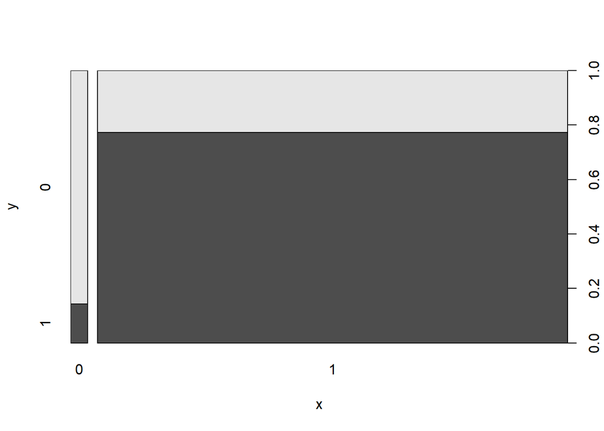

```r
plot(Predictions$SVM, Test_Data[, 35])
```

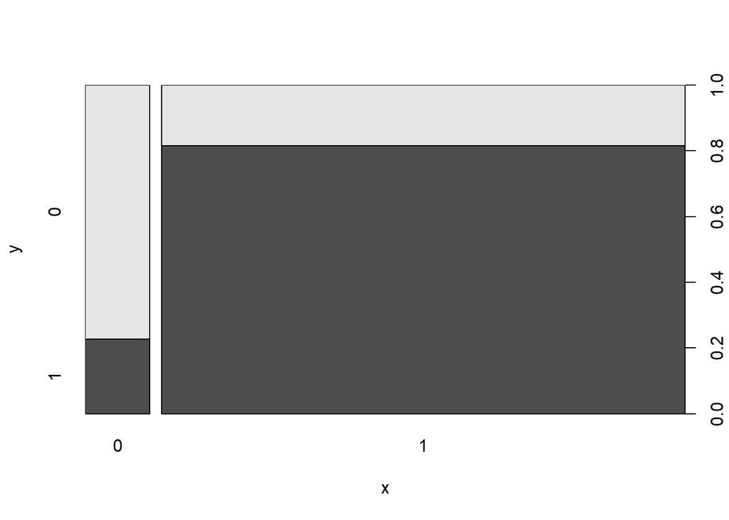

```r
plot(Predictions$RandomForest, Test_Data[, 35])
```

# Problem 2

The file ps3-2.csv contains a data set with the coordinates in degrees (longitude/latitude) of the start and end points of the trips. Each row represents a trip. Use a clustering method in R to divide the start and end points into clusters respectively. The criterion used for clustering is that the maximum distance between the points in each cluster is less than 0.03. Treat a cluster of start points as an origin for a trip, and a cluster of end points as a destination for a trip. Construct an O-D matrix to indicate the number of trips between origins and destinations. Your report must include description of the approach used for clustering, the code, and the results.

```r
EX2_Crude_Data <- read_csv("ps3-2.csv")

Start_Coord <- EX2_Crude_Data[, 1:2]
End_Coord <- EX2_Crude_Data[, 3:4]
```

A distance of $1^{\circ}$ converted to kilometer is equivalent to around 111.3 km. Consequently, the equivalent distance of $0.03^{\circ}$ is $\approx3.339$, or $\approx3339$. The distGeo function calculates the Geodesic distances in meters.

The approach used to cluster the data involves calculating the geodesic distance between the coordinates and then applying a clustering function, cutting off the trees smaller than 3340 meters. This results that the points within the clusters are within that distance.

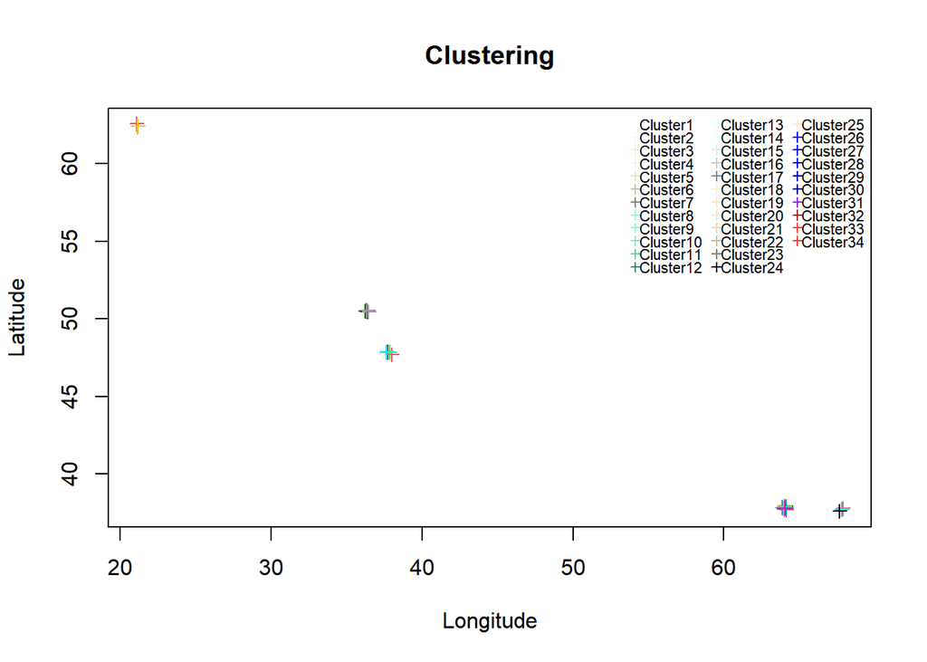

```r
Start_Coord_Dist <- distm(cbind(Start_Coord$`Longitude - Start (deg)`,
                            Start_Coord$`Latitude - Start (deg)`),
                          fun = distGeo)

Start_Coord_Cluster <- hclust(as.dist(Start_Coord_Dist), method = "complete")
Start_Coord$Cluster <- cutree(Start_Coord_Cluster, h = 3340)

plot(x = Start_Coord$`Longitude - Start (deg)`,
     y = Start_Coord$`Latitude - Start (deg)`,
     col=factor(Start_Coord$Cluster), pch = 3,
        box(col="black"),
        main = "Clustering",
        xlab = "Longitude",
        ylab = "Latitude")
          legend("topright", legend=paste("Cluster", unique(Start_Coord$Cluster), sep=""),
                     col=grDevices::colors()[unique(Start_Coord$Cluster)],
                 pch=3, bg="white", bty = "n",
                 ncol = 3, cex = 0.7, y.intersp=0.7,x.intersp=0.3)
```

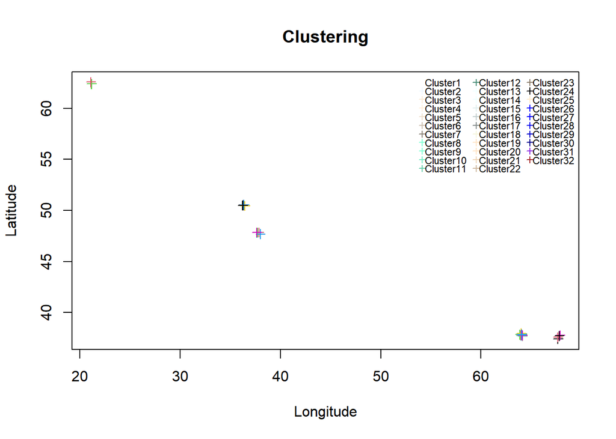

```r
End_Coord_Dist <- distm(cbind(End_Coord$`Longitude - End (deg)`,
                            End_Coord$`Latitude - End (deg)`),
                          fun = distGeo)

End_Coord_Cluster <- hclust(as.dist(End_Coord_Dist), method = "complete")
End_Coord$Cluster <- cutree(End_Coord_Cluster, h = 3340)

plot(x = End_Coord$`Longitude - End (deg)`,
     y = End_Coord$`Latitude - End (deg)`,
     col=factor(End_Coord$Cluster), pch = 3,
        box(col="black"),
        main = "Clustering",
        xlab = "Longitude",
        ylab = "Latitude")
          legend("topright", legend=paste("Cluster", unique(End_Coord$Cluster), sep=""),
                     col=grDevices::colors()[unique(End_Coord$Cluster)],
                 pch=3, bg="white", bty = "n",
                 ncol = 3, cex = 0.7, y.intersp=0.7,x.intersp=0.3)
```

```r
Start_End_Movements <- data.frame(Origin = Start_Coord$Cluster, Destination = End_Coord$Cluster)
Start_End_Movements <- table(Start_End_Movements$Origin,
                             Start_End_Movements$Destination,
                             dnn = c("Origin", "Destination"))

print(Start_End_Movements)
```

```
##       Destination
## Origin  1  2  3  4  5  6  7  8  9 10 11 12 13 14 15 16 17 18 19 20 21 22 23 24 25 26 27 28 29 30 31 32
##     1   1  0  0  0  0  0  0  2  0  0  0  0  0  0  0  0  0  0  0  0  0  0  0  0  0  0  0  0  0  0  0  0
##     2   0  2  0  0  0  0  0  0  0  0  0  0  0  0  0  0  0  0  0  0  0  0  0  0  0  0  0  0  0  0  0  0
##     3   0  0  2  1  9  3  1  0  0  0  0  1  0  0  0  0  0  0  0  0  0  0  0  1  0  0  0  0  0  0  0  0
##     4   0  0  0 12 51  4  0  0  0  0  0  0  0  0  0  0  0  0  0  0  0  0  0  0  0  0  0  0  0  0  0  0
##     5   0  0  6 23  9 80 37  0  0  3  0  5  0  4  0  0  0  0  0  0  0  0  4  0  0  0  0  0  1  0  1  0
##     6   0  0  0 23 51 16 34  0  0  1  0  3  0  1  0  0  0  0  0  0  4  0  5  1  0  0  0  0  0  0  0  0
##     7   0  0  0  7 22 32 13  0  0  0  0  0  0  2  0  0  0  0  0  0  0  0  2  0  0  0  1  0  1  0  0  0
##     8   0  0  0  0  0  0  1  0  0  0  0  0  0  0  0  0  0  0  0  0  0  0  0  0  0  0  0  0  0  0  0  0
##     9   0  0  1  0  8  0  0  0  0  0  0  0  0  0  0  0  0  0  0  0  0  0  0  0  0  0  0  0  0  0  0  0
##     10  0  0  0  1  4  1  0  0  0  0  0  1  0  0  0  0  0  0  0  0  0  0  2  0  0  0  0  0  0  0  1  0
##     11  0  0  0  0  1  1  3  0  0  1  0  0  0  0  0  0  0  0  0  0  0  0  0  0  0  0  0  0  0  0  0  0
##     12  0  0  0  0  0  0  0  3  0  0  0  0  0  0  0  0  2  0  0  0  0  0  0  0  0  0  0  0  0  0  0  1
##     13  0  1  0  0  0  0  0  0  3  0  0  0  0  0  0  0  0  0  0  0  0  0  0  0  0  0  0  0  0  0  0  0
```

[output cut: 19 more lines]

# Problem 3

```r
Ex3_Crude_Data <- read_csv("ps3-1.csv")
Ex3_Crude_Data <- Ex3_Crude_Data[, -c(1, 36)] #Deleting the first and Y collumns
```

The PCA is performed with the prcomp function. The data is centered (making the mean of each variable zero) and scaled, so the variables also have an unitary variance. On summary of the PCA, it can be seen the cumulative percentage of the variable regarding the addition of components.

```r
Ex3_PCA <- prcomp(x = Ex3_Crude_Data, center = TRUE, scale. = TRUE)
summary(Ex3_PCA)
```

```
## Importance of components:
##                           PC1     PC2     PC3     PC4     PC5     PC6     PC7     PC8     PC9    PC10    PC11    PC12   PC13
## Standard deviation     2.7911 1.84073 1.56388 1.36944 1.28970 1.26477 1.22481 1.13228 1.05077 1.01114 0.99200 0.95909 0.9257
## Proportion of Variance 0.2291 0.09966 0.07193 0.05516 0.04892 0.04705 0.04412 0.03771 0.03247 0.03007 0.02894 0.02705 0.0252
## Cumulative Proportion  0.2291 0.32879 0.40072 0.45588 0.50480 0.55185 0.59597 0.63368 0.66615 0.69622 0.72517 0.75222 0.7774
##                           PC14    PC15    PC16    PC17   PC18    PC19    PC20    PC21    PC22    PC23   PC24    PC25    PC26
## Standard deviation     0.89089 0.84594 0.83170 0.79695 0.7536 0.73660 0.67116 0.64028 0.61795 0.59932 0.5947 0.55405 0.55279
## Proportion of Variance 0.02334 0.02105 0.02035 0.01868 0.0167 0.01596 0.01325 0.01206 0.01123 0.01056 0.0104 0.00903 0.00899
## Cumulative Proportion  0.80077 0.82181 0.84216 0.86084 0.8775 0.89350 0.90675 0.91880 0.93004 0.94060 0.9510 0.96003 0.96902
##                           PC27    PC28    PC29    PC30    PC31     PC32      PC33      PC34
## Standard deviation     0.54587 0.52969 0.48965 0.41069 0.25759 0.003086 2.308e-05 3.686e-15
## Proportion of Variance 0.00876 0.00825 0.00705 0.00496 0.00195 0.000000 0.000e+00 0.000e+00
## Cumulative Proportion  0.97778 0.98604 0.99309 0.99805 1.00000 1.000000 1.000e+00 1.000e+00
```

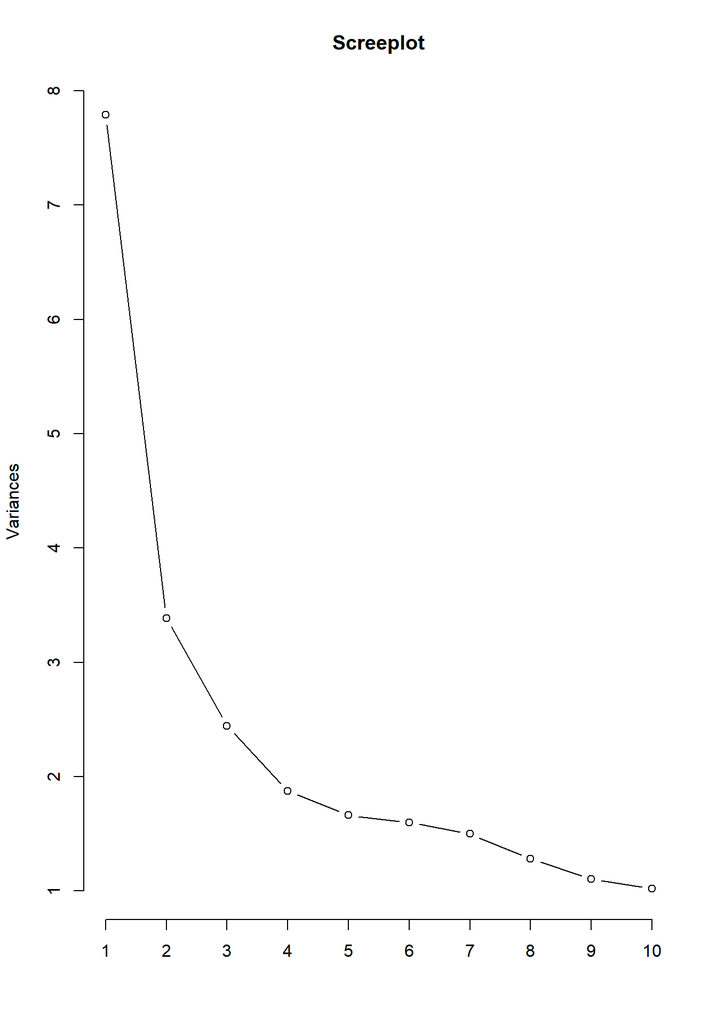

```r
plot(Ex3_PCA, type = "l", main = "Screeplot")
```

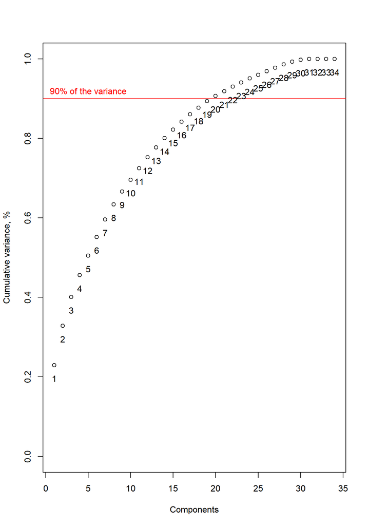

```r
plot(cumsum(Ex3_PCA$sdev^2 / sum(Ex3_PCA$sdev^2)), ylim=0:1,
     ylab = "Cumulative variance, %", xlab = "Components")
abline(h = 0.9, col = "red")
text(y = cumsum(Ex3_PCA$sdev^2 / sum(Ex3_PCA$sdev^2)),x= 1:34, labels = 1:34,
     pos = 1, offset = 1)
text(y = .92, x = 5, "90% of the variance", col = "red")
```

# References

Friedman, Jerome, Trevor Hastie, and Robert Tibshirani. 2001. *The Elements of Statistical Learning*. Vol. 1. 10. Springer series in statistics New York.

James, Gareth, Daniela Witten, Trevor Hastie, and Robert Tibshirani. 2013. *An Introduction to Statistical Learning*. Vol. 112. Springer.